```python
import numpy as np, pandas as pd, scipy.stats, sympy, matplotlib.pyplot as plt,matplotlib as mpl, math
from numpy import random_intel # Used to speed up deneration (~x10)
plt.rc('font', family='serif')
plt.rc('text', usetex=True)
mpl.rcParams['figure.dpi'] = 150
mpl.rcParams['savefig.dpi'] = 300
from IPython.display import display
from sympy import integrate,Symbol,exp,Integral
from sympy.abc import x;from sympy import init_printing;init_printing()
```

# Exercise 5: Variance reduction methods

- Estimate the integral $\int_0^1 e^x dx$ by simulation (the crude Monte Carlo estimator). Use eg. an estimator based on 100 samples and present the result as the point estimator and a confidence interval.
- Estimate the integral $\int_0^1 e^x dx$ using antithetic variables, with comparable computer ressources.
- Estimate the integral $\int_0^1 e^x dx$ using a control variable, with comparable computer ressources.
- Estimate the integral $\int_0^1 e^x dx$ using stratified sampling, with comparable computer ressources.
- Use control variates to reduce the variance of the estimator in exercise 4 (Poisson arrivals). ## Analytical solution

```python
display(Integral(exp(x), (x, 0, 1)) )
print("=")
true = np.exp(1)-1
display(integrate(exp(x), (x, 0, 1)));print("≈");display(np.exp(1)-1)
```

$$\int_{0}^{1} e^{x}\, dx$$

$$-1 + e$$

```
≈
```

$$1.718281828459045$$

## Confidence interval:

\begin{equation} \left[\bar{\theta}+S_\theta t_{\frac{\alpha}{2}}(n-1);\bar{\theta}+S_\theta t_{1-\frac{\alpha}{2}}(n-1)\right] \end{equation}

|  | Mean | Standard diviation | Upper | Lower |
| --- | --- | --- | --- | --- |
| 0 | 1.718481 | 0.014519 | 1.747291 | 1.689672 |

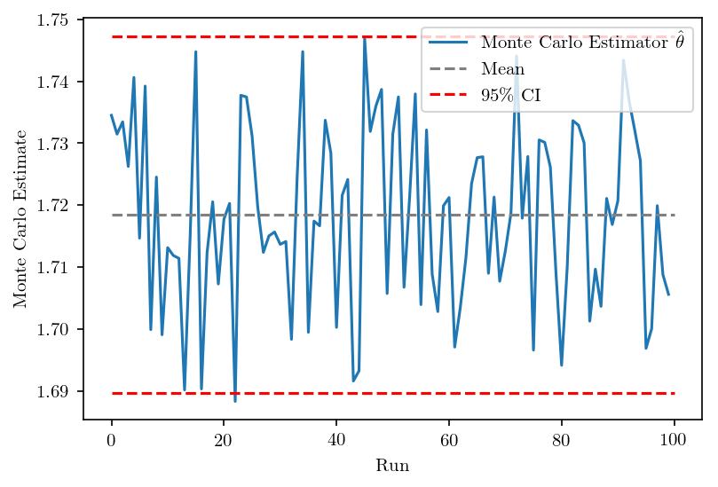

$$0.014519315525718425$$

```python
n = 1000
XBarArr = []
for i in range(100):
    np.random_intel.seed(i)
    U = np.random_intel.rand(n)
    X = np.exp(U)
    XBar = X.sum()/n
    XBarArr.append(XBar)


def stats(array,alpha = 0.05):
    n = len(array)
    mean = np.mean(array)
    #var = 1/(n-1)*(sum([i**2 for i in array])-n*mean**2)
    sd = np.var(array)**(1/2)
    lower,upper =mean + sd*scipy.stats.t.ppf([alpha/2,1-alpha/2],n-1)
    stat = pd.DataFrame(np.array([[mean,sd,upper, lower]]))
    stat.columns = ['Mean','Standard diviation','Upper','Lower']
    display(stat)
    plt.plot(array,label='Monte Carlo Estimator $\hat{\\theta}$')
    plt.plot([0,100],[mean,mean],'--',c='gray',label='Mean')
    plt.plot([0,100],[upper,upper],'--r',label='95\% CI')
    plt.plot([0,100],[lower,lower],'--r')
    plt.legend()
    plt.ylabel("Monte Carlo Estimate")
    plt.xlabel("Run")
    plt.show()
stats(XBarArr)

np.var(XBarArr)**(1/2)
```

```python
conf
```

[output not shown]

# Antithetic variables

General idea: to exploit correlation

```
Correlation = 0.9920449276018409
```

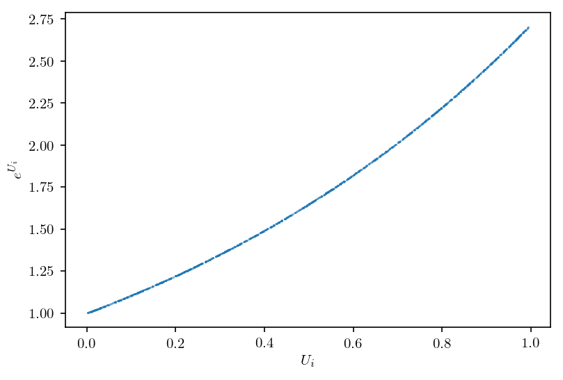

```python
np.random_intel.seed(1)
U = np.random_intel.rand(n)
expU = np.exp(U)
print("Correlation = {}".format(np.corrcoef(U,expU)[0,1]))
plt.scatter(U,expU,0.1)
plt.ylabel("$e^{U_i}$")
plt.xlabel("$U_i$")
plt.show()
```

Seen from the above plot and the calcualted correlation it is very evident that the mante carlo estimator and the uniform distribution are highly postively correlated.

```
100
```

[output not shown]

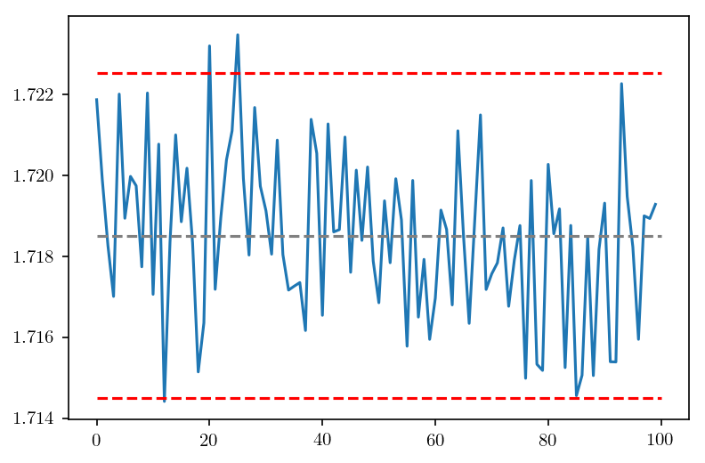

```python
YBarArr = []
for i in range(100):
    np.random_intel.seed(i)
    U = np.random_intel.rand(n)
    expU = np.exp(U)
    Y = (expU+np.exp(1)/expU)/2
    YBar = Y.sum()/n
    YBarArr.append(YBar)
#plt.plot(YBarArr)
np.mean(YBarArr)
stats(YBarArr)
```

## Control variates

Use of covariates

```
100
```

[output not shown]

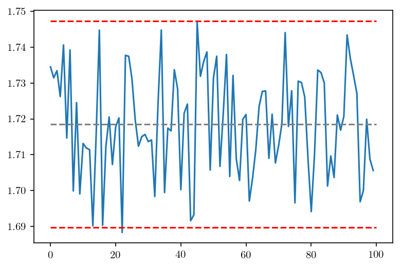

```python
ZBarArr = []
for i in range(100):
    np.random_intel.seed(i)
    U = np.random_intel.rand(n)
    X = np.exp(U)
    c = -np.cov(X,U)[0,1]/U.var()
    Z = X+c*(U-U.mean())
    ZBar = Z.sum()/n
    ZBarArr.append(ZBar)
#plt.plot(ZBarArr)
np.mean(ZBarArr)
stats(ZBarArr)
```

```python
np.random_intel.seed(i)
U = np.random_intel.rand(n)
X = np.exp(U)
c = -np.cov(X,U)[1,0]/U.var()
Z = X+c*(U-U.mean())
ZBar = Z.sum()/n
```

## Stratified sampling

This is a general survey technique: We sample in predetermined areas, using knowledge of structure of the sampling space \begin{equation} W_i = \frac{e^\frac{U_{i,1}}{10}+e^{\frac{1}{10}+\frac{U_{i,2}}{10}}+e^{\frac{2}{10}+\frac{U_{i,3}}{10}}+...+e^{\frac{9}{10}+\frac{U_{i,10}}{10}}}{10} \end{equation} What is an appropriate number of strata? (In this case there is a simple answer; for complex problems not so)

[output not shown]

[output not shown]

[figure not shown]

```python
n = 10
N = 100
W =0
W_iArr = []
for i in range(N):
    np.random_intel.seed(i)
    U = np.random_intel.rand(n)
    W_i = np.array([np.exp((j+U[j])/n) for j in range(n)])/n
    W+=sum(W_i)
    W_iArr.append(W_i.sum())

W=W/N
print(W)
stats(W_iArr)
```